# TimeGPT zero-shot forecast of Lyme disease incidence

Authors

Theo Rashid

Arran Hamlet

Kyle Foreman

I really hope this submission doesn’t win.

I used Nixtla’s TimeGPT, a foundation model for time series, to generate predictions of Lyme disease incidence. Nixtla have [simple API](https://arxiv.org/abs/2310.03589) to generate predictions, and no knowledge of the transformer architecture or training process is required – just bring a dataset. I could have fine-tuned the model for the specific dataset, but I was lazy and tried the zero-shot forecast.

Instead of environmental variables like temperature (high temperature leads to faster tick growth and virus replication rates, and people go outside more) and rainfall (winter rains are a good habitat for ticks), I just used the provided population covariate (averaged for the forecasts) and an [indicator variable from the ONS](https://geoportal.statistics.gov.uk/search?q=PRD_SAM_NPARK&sort=Date%20Created%7Ccreated%7Cdesc) that classifies whether the district is urban or not.

TimeGPT generates uncertainty intervals using conformal prediction. This would have been even more sad because [the conformal prediction guy on twitter has a vendetta against Bayesians](https://x.com/predict_addict/status/1908254578472345935). Luckily, Nixtla wouldn’t let me use conformal prediction because I had too few data-points. So I fit an `ARIMA(1,1,1)` model and used those for the confidence intervals.

Both the TimeGPT predictions and the uncertainty intervals were clipped at zero, because you can’t have negative incidence, and because it wasn’t obvious how to use a link function.

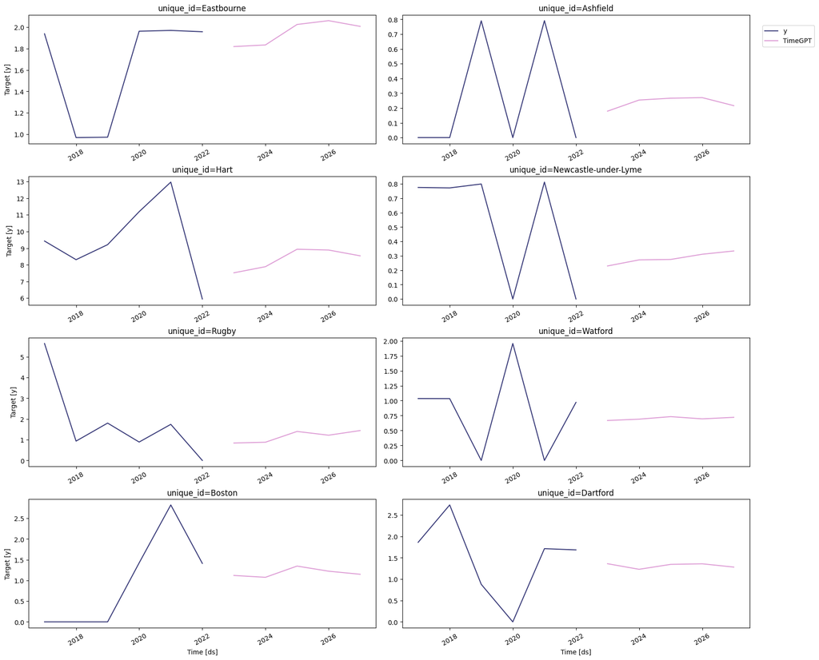

From the plot Nixtla’s API provides, the mean estimates look reasonable.

Hopefully this submission does not rank too highly and we do not have to give up on proper principled forecasting models.